# Faculty of Information Technology

# FIT3152 - Data Analytics

## Assignment 1, Semester 1, 2024

**Name:** Rhyme Bulbul

**Student ID:** 31865224

**Project:** Analysis of country-level predictors of pro-social behaviours to reduce the spread of COVID-19 during the early stages of the pandemic

**AI statement:** Generative AI was not used in this assignment

## Task 1: Descriptive analysis and pre-processing

#### 1(a)

A condensed version of the data gathered for the PsyCorona baseline study, a psychological survey investigating pro-social behaviours in several nations during the COVID-19 epidemic, is contained in the file `PsyCoronaBaselineExtract.csv`, by Van Lissa et al. (2002).

We start by taking a unique sample of the dataset based on my student ID, and attaching the data to the R search path for ease of variable use

```r
rm(list = ls())
set.seed(31865224)
cvbase = read.csv("PsyCoronaBaselineExtract.csv")
cvbase <- cvbase[sample(nrow(cvbase), 40000), ] # 40000 rows
```

We will require the help of a few libraries, so let’s import those

```r
library(ggplot2)
library(dplyr)
library(tidyr)
```

It is helpful to learn about a dataset’s features and properties before working on it

```r
dim(cvbase)
as.data.frame(sapply(cvbase, class))  # get data types of each column
summary(cvbase, na.rm = TRUE)
```

In this case, we will run the dimensions method, to find out the data frame has 40,000 rows, given we have sampled it to be so when reading it in, and 52 columns.

The only text attributes in the dataframe appear to be `coded_country` and the `Rank Order of Life` columns, while the rest are integer data

According to the codebook extract, every column aside from `employstatus`, `gender`, `age`, `edu`, and `coded_country` contains ordinal data in the form of numbers that represent degrees of agreement for things like age group, education level, and level of agreement. Different `gender`, `age`, and `education` categories are coded by the integer values in their respective columns. Each record may only have a maximum of one employstatus column with a value of 1, indicating the employee’s employment status.

We may infer that the numerical attributes have different ranges from the `summary()` output. Survey questions evaluating a two-sided degree of agreement vary from a negative number to its modulus, while those measuring a one-sided degree of agreement go from 1 to a larger positive number, such 4 or 5.

We are able to use the following, to understand `coded_country` better

```r
sort(unique(cvbase$coded_country))  # get unique country names in sorted order
table(cvbase$coded_country)         # get number of entries for each country
max(table(cvbase$coded_country))   # get maximum number of entries, and their corresponding countries
which(table(cvbase$coded_country) == max(table(cvbase$coded_country)))
```

```r
min(table(cvbase$coded_country))   # get minimum number of entries, and their corresponding countries
which(table(cvbase$coded_country) == min(table(cvbase$coded_country)))
```

Missing values are present in all columns, however this is the norm as surveys of this nature do not require participants to answer all questions. The `employstatus` columns appear to be the biggest culprit, given each participant will only pick one out of the 10 categories. In this dataframe, `employstatus_3` seems to have the least missing values, while `employstatus_8` has the highest number. Potentially, this could imply that the majority of participants are working 40 hours or more, while a small number of people who are disabled may be out of work.

Another point to note is the mean age group in this dataframe amounts to 2.905, which indicates that the majority of participants are likely to be aged between 35-44 years. This could indicate working-class adults with concise lifestyle, and are studied accordingly to research the outcomes covid had on people.

### 1(b)

```r
# for (i in 1:10) {
#   cvbase[, i][is.na(cvbase[, i])] <- 0
# }
# for (i in 37:44) {
#   cvbase[, i][is.na(cvbase[, i])] <- 0
# }

cvbase[is.na(cvbase)] <- 0

# for (i in 1:52) {
#   cvbase[, i][is.na(cvbase[, i])] <- 0
# }
```

## Task 2: Focus country vs all other countries as a group

### 2(a)

My designated country is Croatia. We will start by creating bar charts for each group of countries, where the y-axis represents the survey questions, and the x-axis represents the mean of each questions’ response. Below, we will create data frames for the mean values utilizing `ggplot2`, excluding non-numerical attributes such as `coded_country`.

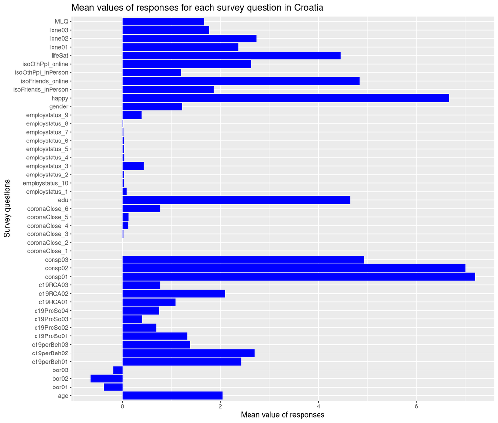

```r
croatia <- cvbase[cvbase$coded_country == "Croatia", ]
others <- anti_join(cvbase, croatia)

numeric_cols <- sapply(croatia, is.numeric)  # Find numeric columns
means <- colMeans(croatia[, numeric_cols], na.rm = TRUE)  # Calculate means

#means <- colMeans(croatia[, !names(croatia) %in% c("coded_country")], na.rm = TRUE)
croatia_means <- data.frame(mean = means)

numeric_cols <- sapply(others, is.numeric)  # Find numeric columns
others_means <- colMeans(others[, numeric_cols], na.rm = TRUE)  # Calculate means
#means <- colMeans(rem[, !names(rem) %in% c("coded_country")], na.rm = TRUE)
others_means <- data.frame(mean = others_means)

croatia_plot <- ggplot(croatia_means) +
  geom_bar(mapping = aes(x = rownames(croatia_means), y = mean), stat = "identity",
    fill = "blue") +
  coord_flip() +
  labs(x = "Survey questions", y = "Mean value of responses",
    title = "Mean values of responses for each survey question in Croatia")

rem_plot <- ggplot(others_means) +
  geom_bar(mapping = aes(x = rownames(others_means), y = mean), stat = "identity",
    fill = "red") +
  coord_flip() +
  labs(x = "Survey questions", y = "Mean value of responses",
    title = "Mean values of responses for each survey question in the rest of the world")

croatia_plot
```

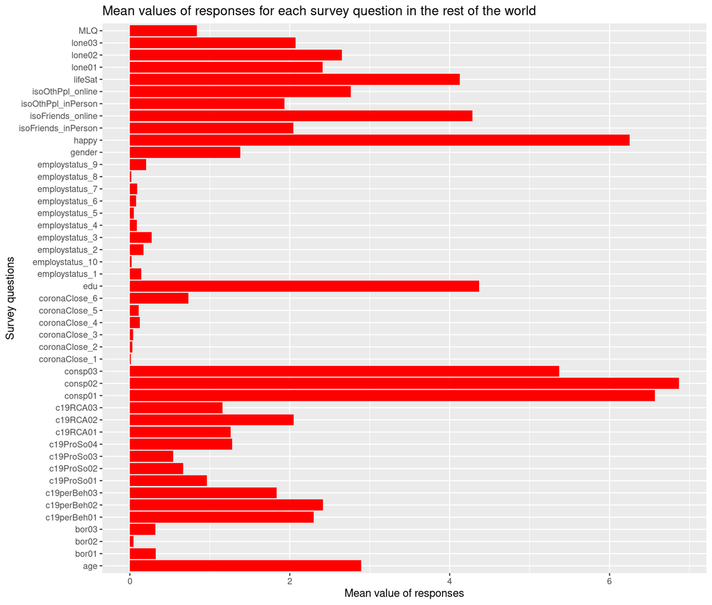

```r
rem_plot
```

### 2(b)

Let’s start by taking a peek at the correlation between predictors for pro-social attitude for Croatia. The `cor()` function is used and the correlation matrix is visualised with a heatmap.

```r
# # Select only numeric columns from the dataset
numeric_croatia <- croatia[sapply(croatia, is.numeric)]
#
# # Calculate correlation matrix for Croatia
cro_cor <- cor(numeric_croatia, use = "complete.obs")
```

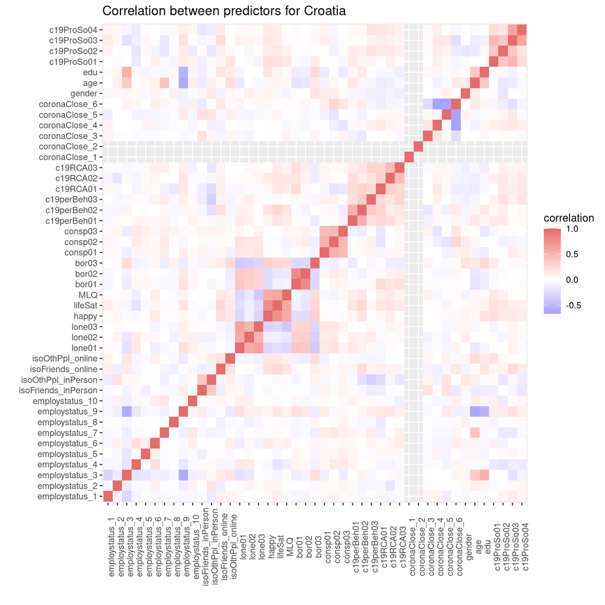

```r
# Remove diagonal elements from correlation matrix
#diag(cro_cor) <- NA

# Reshape matrix to long format for plotting
cro_melted <- reshape2::melt(cro_cor, na.rm = TRUE)

# Create correlation plot for Croatia
cro_cor_plot <- ggplot(data = cro_melted, aes(x = Var1, y = Var2, fill = value)) +
  geom_tile() +
  scale_fill_gradient2(low = "#6b74ff", mid = "white", high = "#e46c6c", midpoint = 0) +
  labs(title = "Correlation between predictors for Croatia", x = "", y = "",
       fill = "correlation") +
  theme(axis.text.x = element_text(angle = 90))

cro_cor_plot
```

Tiles that are red or blue denote positive or negative correlation, respectively, and turn white as correlation gets closer to zero. Numerous examples of substantial association between predictors can be seen in this heatmap; nevertheless, the portion displaying the correlation between pro-social views and all other traits is quite weak. This suggests that the characteristics might not be a very good indicator of pro-social sentiments in Croatia.

We can determine how well the replies predict the pro-social attitude question by fitting a linear regression model of each pro-social attitude against the qualities. Additionally, we will be able to identify the most accurate predictions.

```r
prds <- NULL
mdl <- NULL

model_eval <- function(model) {
  rsqr <- summary(model)$r.squared
  a_rsqr <- summary(model)$adj.r.squared
  sig <- which(summary(model)$coefficients[-1, 4] < 0.001) + 1
  preds <- rownames(summary(model)$coefficients[sig, , drop = FALSE])
  coefs <- summary(model)$coefficients[sig, 1]

  return(list(rsqr, a_rsqr, preds, coefs))
}

fitted_croatia1 <- lm(c19ProSo01 ~ .,
  data = subset(croatia, select = -c(coded_country, c19ProSo02, c19ProSo03, c19ProSo04)))
fitted_croatia2 <- lm(c19ProSo02 ~ .,
  data = subset(croatia, select = -c(coded_country, c19ProSo01, c19ProSo03, c19ProSo04)))
fitted_croatia3 <- lm(c19ProSo03 ~ .,
  data = subset(croatia, select = -c(coded_country, c19ProSo01, c19ProSo02, c19ProSo04)))
fitted_croatia4 <- lm(c19ProSo04 ~ .,
  data = subset(croatia, select = -c(coded_country, c19ProSo01, c19ProSo02, c19ProSo03)))

cat("Summary of models for predicting pro-social attitudes in Croatia\n\n")
```

```
## Summary of models for predicting pro-social attitudes in Croatia
```

```r
counter <- 1
for (model in list(fitted_croatia1, fitted_croatia2, fitted_croatia3, fitted_croatia4)) {
  cat("C19ProSo0", counter, "\n", sep = "")
  res <- model_eval(model)
  cat("R-squared value:", res[[1]], "\n")
  cat("Adjusted R-squared value:", res[[2]], "\n")
  cat("Significant predictors with p-value < 0.001:\n")
  cat(res[[3]], "\n")
  cat("Coefficients of predictors:\n")
  cat(res[[4]], "\n")
  cat("\n")
  for (pred in res[[3]]) {
    mdl <- c(mdl, paste0("Croatia C19ProSo0", counter))
  }
  prds <- c(prds, res[[3]])
  counter <- counter + 1
}
```

```
## C19ProSo01
## R-squared value: 0.4686053
## Adjusted R-squared value: 0.2519858
## Significant predictors with p-value < 0.001:
##
## Coefficients of predictors:
##
##
## C19ProSo02
## R-squared value: 0.3355854
## Adjusted R-squared value: 0.06474127
## Significant predictors with p-value < 0.001:
##
## Coefficients of predictors:
##
##
## C19ProSo03
## R-squared value: 0.4872678
## Adjusted R-squared value: 0.278256
## Significant predictors with p-value < 0.001:
## isoFriends_online
## Coefficients of predictors:
## 0.1795645
##
## C19ProSo04
## R-squared value: 0.3617789
## Adjusted R-squared value: 0.1016124
## Significant predictors with p-value < 0.001:
## rankOrdLife_4D
## Coefficients of predictors:
## 6.462742
```

The fact that the majority of the survey items are deemed subjective makes the models’ arguably low R-squared values predictable. For instance, different individuals interpret financial hardship differently and perceive various levels of serenity differently. Since Croatia is a large, populated nation with a wide range of living standards, its several regions are like independent nations with their own economies, healthcare systems, and general levels of satisfaction. Because of this, it is challenging to forecast the pro-social attitude reactions with consistency.

### 2(c)

The previous code blocks for 2(b) are modified, but with the `rem` dataset instead of `croatia`, to produce a similar correlation matrix for the rest of the world. To keep the report concise, variants of code that have been modified further on, can be found in the **Appendix**.

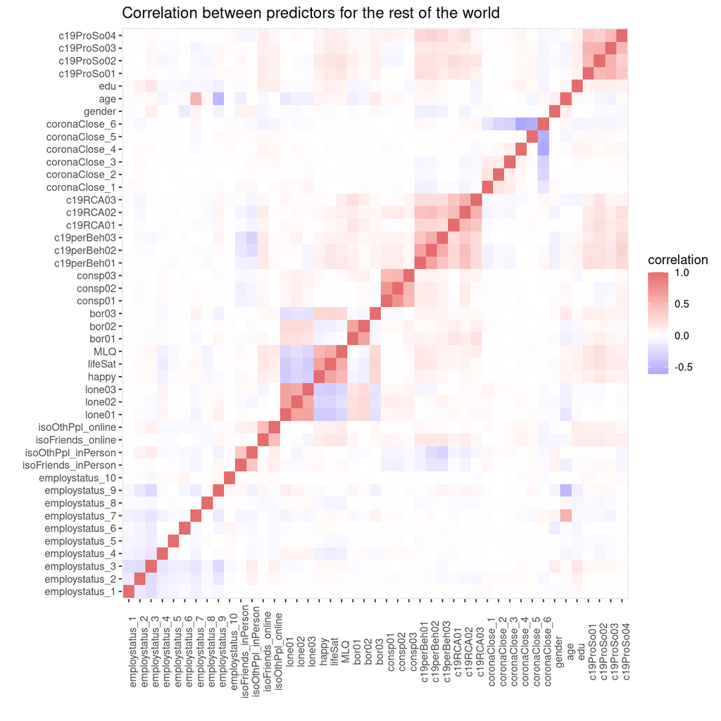

```r
rem_cor_plot
```

When we compare the two heatmaps we currently have, we see that `cro_cor_plot` has tiles coloured in a deeper shade of red, which suggests a larger overall correlation between the predictors. Apart from having lighter tiles, `rem_cor_plot` appears “cleaner” due to a reduced dispersion of coloured tiles. However, since the subsections in both plots appear fairly similar, we can make an initial guess that the attributes for both groups of data should predict pro-social attitudes with roughly similar performance by concentrating on the heatmap subsections that show the correlation between pro-social attitudes and all other attributes.

```
## Summary of models for predicting pro-social attitudes in the rest of the world
```

```
## C19ProSo01
## R-squared value: 0.1280411
## Adjusted R-squared value: 0.12646
## Significant predictors with p-value < 0.001:
## employstatus_6 employstatus_7 employstatus_8 employstatus_10 isoFriends_inPerson isoOthPpl_inPerson isoFriends_online isoOthPpl_online lone01 lone02 lifeSat MLQ bor01 bor03 consp02 consp03 rankOrdLife_6A c19perBeh01 c19perBeh02 c19RCA01 coronaClose_4 gender edu
## Coefficients of predictors:
## -0.09356577 -0.2272962 -0.1897203 0.3730428 0.01719855 0.02667376 0.01609172 0.01721033 0.0606518 -0.0347284 0.05699928 0.08522657 0.03380256 0.05516177 -0.02498478 0.01205637 0.3784374 0.1386828 0.09563573 0.07648498 0.1293874 0.06462325 0.03438064
##
## C19ProSo02
## R-squared value: 0.1766909
## Adjusted R-squared value: 0.1751979
## Significant predictors with p-value < 0.001:
## employstatus_3 employstatus_4 employstatus_5 employstatus_8 employstatus_10 isoFriends_inPerson isoFriends_online isoOthPpl_online lone01 lone02 lone03 happy lifeSat MLQ bor01 bor03 consp01 consp02 consp03 rankOrdLife_1A rankOrdLife_1B rankOrdLife_1C rankOrdLife_1D rankOrdLife_1E rankOrdLife_1F r…
## Coefficients of predictors:
## 0.1072481 -0.1977689 -0.1317748 -0.3161566 0.2091906 0.03416122 0.0152765 0.02820841 0.05811839 -0.04047441 0.03497465 0.02425677 0.09393153 0.1042817 0.061403 0.03223252 -0.02523271 -0.03561827 0.01287189 -1.774199 -1.999203 -1.738606 -1.69142 -1.812051 -2.194264 0.3825916 0.6207841 0.5895402 0.…
##
## C19ProSo03
## R-squared value: 0.1199772
## Adjusted R-squared value: 0.1183814
## Significant predictors with p-value < 0.001:
## employstatus_3 employstatus_7 employstatus_10 isoFriends_inPerson isoOthPpl_inPerson isoOthPpl_online lone03 lifeSat MLQ bor01 bor03 consp02 consp03 rankOrdLife_2A rankOrdLife_2B c19perBeh01 c19perBeh02 c19perBeh03 c19RCA01 c19RCA03 coronaClose_1 coronaClose_6 age edu
## Coefficients of predictors:
## 0.1555728 -0.2152103 0.3369801 0.02274039 0.02160123 0.02621581 0.066345 0.09423445 0.0588311 0.02820003 0.0492747 -0.04277474 0.0114348 -0.4510506 -0.5339868 0.08363566 0.08775189 0.0628635 0.08329588 -0.02228253 0.2390468 -0.1534728 -0.06731613 0.0580925
##
## C19ProSo04
## R-squared value: 0.17178
## Adjusted R-squared value: 0.1702782
## Significant predictors with p-value < 0.001:
## employstatus_2 employstatus_3 employstatus_10 isoFriends_online lone02 lone03 lifeSat MLQ bor02 bor03 consp01 consp02 rankOrdLife_3B rankOrdLife_3D c19perBeh01 c19perBeh02 c19perBeh03 c19RCA01 c19RCA02 c19RCA03 coronaClose_3 coronaClose_6 edu
## Coefficients of predictors:
## 0.09869336 0.1272541 0.2820308 0.01248981 0.03724033 0.03827886 0.07587075 0.02828067 0.02557799 0.04581936 0.02680734 -0.01501148 -0.4641057 -0.5258734 0.07938804 0.1655886 0.104302 0.06603338 0.104536 -0.05392971 0.1612792 -0.1536674 0.03288289
```

Note: the lines for predictor names and their coefficients are too long and were cut off instead of wrapped when this PDF was knitted from my R Markdown file. The cut-off lines are, in order, as follows:

`0.06154919` `0.0652525` `0.1005851` `0.3293603` `0.06135636` `0.05886684` `0.08799994` `0.1034505` `0.0727743` `0.05776118` `0.142124` `0.02873322`

`0.04854233` `0.06002516` `0.06926414` `0.04935493` `0.04810877` `-0.03626116` `0.1502406` `0.0650781` `0.06608606` `-0.0901943` `-0.07940344` `0.06139211` `0.1117521` `0.1321387` `0.08202972` `0.06169359` `0.1511349` `-0.05740599` `0.05113085`

`0.05042581` `0.04464075` `0.06039361` `0.07098512` `0.1348678` `0.07466859` `0.3418363` `0.09238179` `0.05582841` `0.08829495` `0.07615688` `0.0830227` `0.1792569` `-0.05783799` `0.03418924`

`0.07070157` `0.08621845` `0.1716264` `0.04722402` `0.06153325` `0.348768` `0.04779941` `-0.06649288` `-0.05701471` `0.07318474` `0.08059154` `0.2330507` `0.04257108` `0.05811818` `0.09548559`

```r
# summ_table <- table(predictors = prds, models = mdl)
#
# # reorder the columns
# summ_table <- summ_table[, c("Croatia C19ProSo01", "Croatia C19ProSo02", "Croatia C19ProSo03",
#   "Croatia C19ProSo04", "RoW C19ProSo01", "RoW C19ProSo02", "RoW C19ProSo03",
#   "RoW C19ProSo04")]
#
# summ_table_vis <- ggplot(data = as.data.frame(summ_table)) +
#   geom_tile(mapping = aes(x = models, y = predictors, fill = Freq, colour = "black")) +
#   scale_fill_gradientn(colours = c("pink", "green")) +
#   theme(legend.position = "none") +
#   scale_x_discrete(position = "top") +
#   scale_y_discrete(limits = rev) +
#   labs(x = "Models", y = "Predictors",
#     title = "Table of significant predictors for each model")
#
# summ_table_vis
```